# 第四周：第三章 重点解析

[figure not shown]

[figure not shown]

School of Social Development

多源数据分析与实践 · Week 4

[interactive chart not shown]

# 第三章 重点解析

主讲人：刘贇喆 副教授 | 华东师范大学 社会发展学院

数据可视化导论 · ggplot2 包 · 常用图形 · 制图规范 · 可视化美化

[interactive chart not shown]

目录

**目录** CONTENTS

1.0 数据可视化导论

01

SECTION**01 / 05**

## 1.0数据可视化导论

Introduction to Data Visualization

1.0 数据可视化导论

## 探索与诊断

Explore & Diagnose

统计摘要很接近，数据的形态也会一样吗？

ANSCOMBE’S QUARTET · 1973

### 四组数据，一组相近的摘要

**每组观测**

11 条

**均值**

*x* = 9 · *y* ≈ 7.50

**样本方差**

*x* = 11 · *y* ≈ 4.12–4.13

**相关与拟合**

*r* ≈ 0.816 · ŷ ≈ 3 + 0.5*x*

**看图后，差异才显现**

1. **I**近似线性
2. **II**弯曲关系
3. **III**纵向离群点
4. **IV**高杠杆点

Anscombe（1973）构造的教学数据；四组各 11 条，并非现实观察样本。

? **相近的统计量，能讲完数据的故事吗？** 点击左侧按钮，对照四幅散点图

四组同尺度 观测点 线性拟合

[figure not shown]

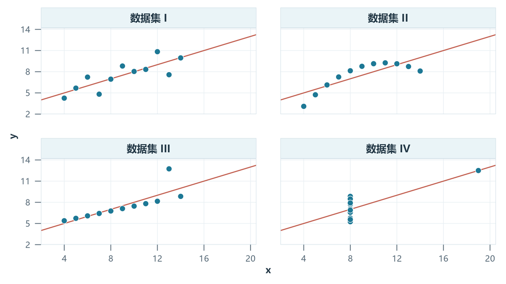

四组横纵轴范围一致；蓝点为观测，橙线为线性拟合。

1.0 数据可视化导论

## 解释与推断

Explain & Infer

图形提示差异与走势；解释原因仍需研究设计

THREE READING TASKS

### 从数据中看见什么？

点击任务切换图形；把鼠标移到数据点，可查看对应观测。

图形展示可核查的观测与模型结果；不能仅凭图中的关系作因果判断。

OBSERVED DATA · 2007–2009

### 三种企鹅的体重分布

悬停读数 · 拖拽缩放

正在准备可交互图…

**原始点保留组内差异；菱形标出各组中位数。** Palmer Penguins，体重有效记录 342 只；Horst、Hill 与 Gorman（2020），CC0。

1.0 数据可视化导论

## 沟通与传播

Communicate & Share

同一数据，三种表达。

THREE VIEWS

### 从摘要到证据

共同尺度，先读变化方向与幅度。

### 城市人口占比 · 七地区中位数

[figure not shown]

来源：世界银行 WDI（1990、2023）。区域中位数按经济体等权；各国城市定义有差异。图示仅作描述。

1.0 数据可视化导论

## 《天演论》与信、达、雅

Yan Fu's Principles of Translation

YAN FU · 1854—1921

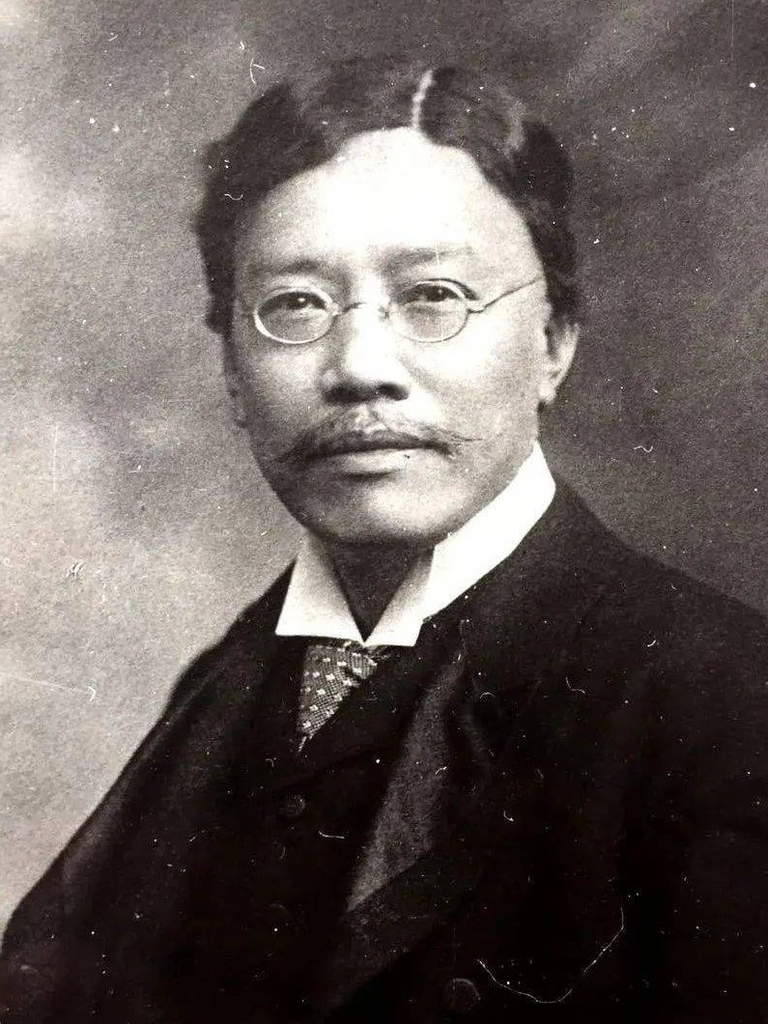

严复 · 肖像

[figure not shown]

《天演论》· 书影

近代中国重要的**翻译家与思想家**《天演论》的译者翻译西方学术著作，传播近代学科知识

> “译事三难：**信、达、雅。**”

> “求其信已大难矣”

> “顾信矣不达，虽译犹不译也”

> “故信达而外，求其尔雅”

> 严复《天演论·译例言》 · 1898 · 节引

2.0 ggplot2 包

02

SECTION**02 / 05**

## 2.0ggplot2 包

The ggplot2 Package

2.0 ggplot2 包

## ggplot2：把作图写成语法

The Grammar of Graphics in R

包含

**ggplot2**tidyverse 核心可视化包

语法来源**借鉴 Leland Wilkinson《The Grammar of Graphics》，Hadley Wickham 开发了 ggplot2。**

BUILD A GRAPH · 由下向上

一层一层出图**00 / 04**

### 从数据到图形，逐层组合

**ggplot2 语法**

**DATA**Dataset`data_plot %>%`

**AES**Aesthetics`ggplot(aes(x = date, y = uempmed)) +`

**GEOM**Geometric objects`geom_line() +`

**LABS + THEME**Labels + theme`labs(x = "年份", y = "周") + theme_minimal()`

`%>%` 把数据送入 `ggplot()`；`+` 继续添加图层与设置。

2.0 ggplot2 包

## 一张图如何“写”出来？

Data · Aesthetics · Geometry · Presentation

BUILD A GRAPH · 由下向上

R CODE **· 数据**

本层新增**01 / 04**

```
library(tidyverse)
data_plot <- ggplot2::economics %>%
  filter(date >= as.Date("2007-01-01"),
         date <= as.Date("2015-04-01")) %>%
  select(date, uempmed)
head(data_plot)
```

数据预览

### 100 条月度记录

真实数据 · 主题适配示意

head(data_plot) 前 6 / 100 行

| # | date <date> | uempmed <dbl> · 周 |
| --- | --- | --- |
| 1 | 2007-01-01 | 8.3 |
| 2 | 2007-02-01 | 8.5 |
| 3 | 2007-03-01 | 9.1 |
| 4 | 2007-04-01 | 8.6 |
| 5 | 2007-05-01 | 8.2 |
| 6 | 2007-06-01 | 7.7 |

uempmed → y失业持续时间中位数（周）

date → x年份

**head(data_plot) 显示前 6 行；作图使用全部 100 行。**FRED UEMPMED · 2007—2015

2.0 ggplot2 包

## 只换 geom，换出三种图

Same Data · Same Mapping · Three Geometries

**geom_gallery.R**

数据

```
library(tidyverse)
data_plot <- ggplot2::txhousing %>%
  filter(city == "Houston", year == 2013)
```

共用映射与坐标

```
base_plot <- data_plot %>%
  ggplot(aes(x = month, y = sales)) +
  scale_x_continuous(breaks = 1:12, limits = c(.5, 12.5)) +
  scale_y_continuous(limits = c(0, 9000),
                     breaks = c(0, 3000, 6000, 9000)) +
  labs(x = "月份", y = "成交套数") +
  theme_minimal(base_size = 16)
```

**只替换 geom**点击查看对应图形

### 等待绘制图层

base_plot**+***geom_…*

点击左侧任意 geom，查看它生成的图形。

3.0 常用图形

03

SECTION**03 / 05**

## 3.0常用图形

Common Chart Types

3.0 常用图形

## 先问目的，再选图

Start with the Question, Then Choose a Chart

哪一类更大？

随时间如何变化？

变量如何一起变化？

数值集中在哪？

各部分占多少？

差异出现在哪里？

4.0 制图规范

04

SECTION**04 / 05**

## 4.0制图规范

Figure Design Guidelines

4.0 制图规范

## 一张图，要交代什么？

A Chart Should Explain Itself

READ THE CHART**核对四处**

先辨认对象、时间和变量，再核对尺度、编码与来源。

HOUSING SALES · HOUSTON MLS

### Houston MLS 区域月度住房成交量

2012—2013 年 · 每月一条记录

20122013

[figure not shown]

**数据来源** ggplot2::txhousing**统计口径** Houston MLS 区域 · 当月成交套数（24 条有效记录）

4.0 制图规范

## 这张图，哪里会误导？

What Makes a Chart Misleading?

观察 01**7 月成交量看起来比 6 月高出多少？**

答案 01

### 纵轴从 7,500 起

柱长的视觉差距被放大了。两个月实际相差 **533 套**，约为 6 月的 **6.7%**。

怎么改

用柱形比较总量时，纵轴通常从 **0** 起。

观察 02**两段折线的斜率可以直接比较吗？**

[figure not shown]

答案 02

### 月份被等距放置

**1→2 月**只隔 1 个月，**2→12 月**隔了 10 个月。等距连线会误导斜率判断。

怎么改

按真实月份排布并补齐中间月份；若只显示三个月，断线并说明省略。

观察 03**Q4 份额下降，成交套数也下降了吗？**

[figure not shown]

答案 03

### 份额下降，套数上升

Q4 占比 **24.7% → 22.9%**，但实际成交 **16,925 → 18,488 套**。

怎么改

判断数量增减时，同时呈现全年总量或季度套数。

观察 04**这条线能说明“随着年龄增长，病例先增后减”吗？**

[figure not shown]

答案 04

### 有序年龄组，仍是类别

各点是不同年龄组的病例数，**75 岁以上**还是开放区间。本题不宜用折线暗示连续年龄轨迹；样本病例数也不是发病风险。

怎么改

本题用点图或柱形图；有序年龄组的均值若连线，须注明仅表示组间梯度。

观察 05**两根柱几乎等高，两地成交量也接近吗？**

[figure not shown]

答案 05

### 两图纵轴上限不同

一幅到 **9,000**，另一幅到 **3,500**。柱子近似等高，实际 Houston 为 **8,468** 套，Austin 为 **3,376** 套。

怎么改

跨图比较同一指标的绝对量，应统一单位、纵轴范围和刻度。

观察 06**两个圆的面积差，和航班数差一致吗？**

答案 06

### 半径放大了面积差

航班数之比约 **1.45∶1**。图中半径按数值增大，圆面积之比变成约 **2.11∶1**。

怎么改

气泡的**面积**对应数值，半径按平方根缩放，并保留数值标签。

**01 / 06**图中数值来自 ggplot2::txhousing · Houston MLS 区域

5.0 可视化美化

05

SECTION**05 / 05**

## 5.0可视化美化

Visual Styling

5.0 可视化美化

## 先准确，再美化

Accuracy Before Styling

同一数据、同一尺度，只调整信息的呈现方式。

01 / 基础图**信息完整，重点尚不突出**

[figure not shown]

12 个月的成交套数均真实呈现；较密的网格分散了注意力。

02 / 精修图**弱化干扰，直接标注重点**

[figure not shown]

数值与 0—9,000 纵轴不变；标出最高、最低点和月均虚线。

5.0 可视化美化

## 均值之外，看见分布

Beyond the Mean

01 / 概括位置**均值点图**

[figure not shown]

每组一个均值，适合快速比较中心位置；组内差异尚未呈现。

02 / 分布与比较**云雨图**

[figure not shown]

100 g 分箱点阵；Dunn–Holm：ns 不显著，*** 为 *P* < 0.001。

5.0 可视化美化

## 色盘实验室

Color and Shape Change How We Read Charts

固定 142 个点，比较配色与点形的可读性。

COLOR LAB / 01

### 同一幅图，换配色与点形

数据和坐标始终不变。

选择分类色盘

柔和色相，适合看整体。

选择散点样式

**类别**用离散色；检查投影与灰度辨识。

**数值**连续用顺序色带；有基准的偏差用发散色带。

影视配色只作灵感；图上色值已调校。

GAPMINDER · 2007**收入与预期寿命**每点 = 一个国家或地区

[figure not shown]

非洲 · 52美洲 · 25亚洲 · 33欧洲 · 30大洋洲 · 2

数据：Gapminder 2007 · 142 个国家或地区；颜色和点形表示大洲，坐标不变。

5.0 可视化美化

## 配色灵感：从画面到图表

From Images to Charts

### 顶刊图配色

PNAS

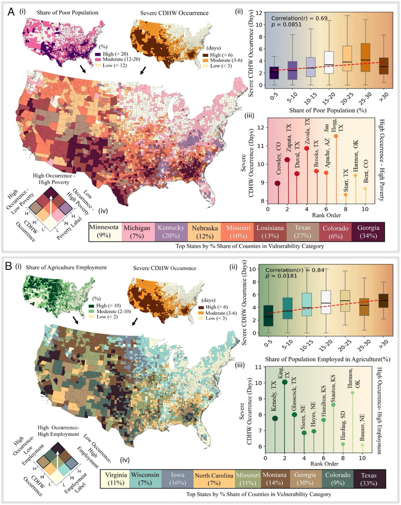

### 配色灵感

社交媒体

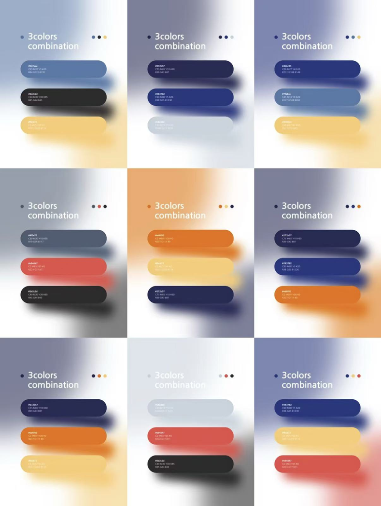

### 影视作品

《你的名字。》

[figure not shown]

### 日常场景

相机与小狗

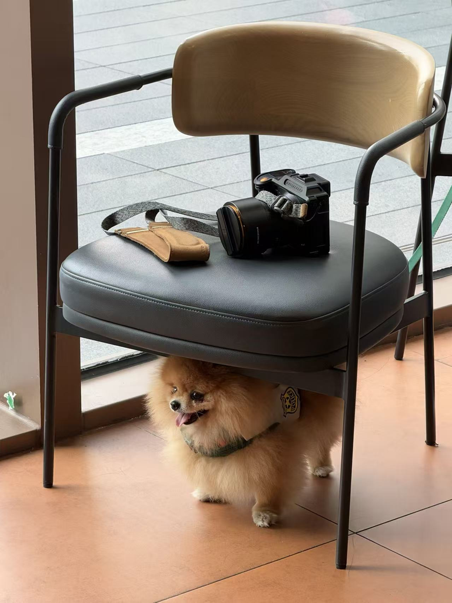

多源数据分析与实践 · Week 4

[interactive chart not shown]

# Thanks

第四周：第三章 重点解析

主讲人：刘贇喆 副教授 | 华东师范大学 社会发展学院

01

08

滚轮 / 方向键 / 空格切换

00:00:00